# Will_Lab9

## EX. 13.4.6 #3

> *Is there a relationship between the age of a plane and its delays?*

### Solution 1

Counter to our intuition, The minimal time of departure dealay tends to increase slightly with the aging of the plane.

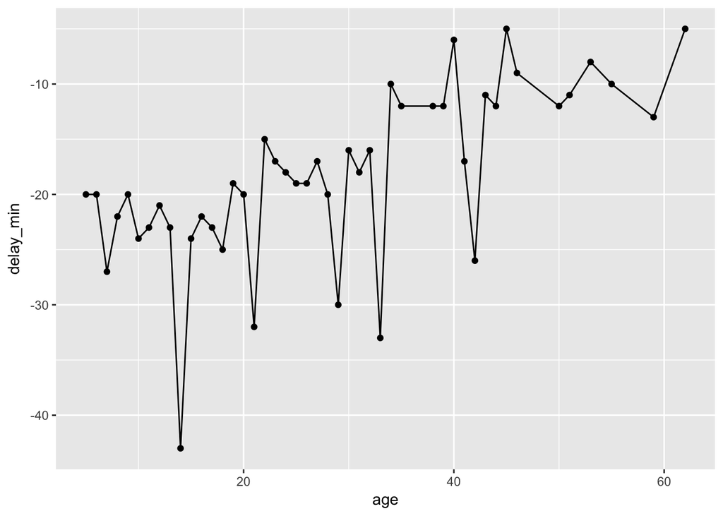

```r
### Specify the the ages of the planes.
ages_plane <-
  planes %>%
  mutate(age = 2018 - year) %>%
  select(tailnum, age)

### Minimal minutes of delay
flights %>%
  inner_join(ages_plane, by = "tailnum") %>%
  group_by(age) %>%
  ### Here we use the average
  filter(!is.na(dep_delay)) %>%
  summarise(delay_min = min(dep_delay)) %>%
  ggplot(aes(x = age, y = delay_min)) +
      geom_point() +
      geom_line()
```

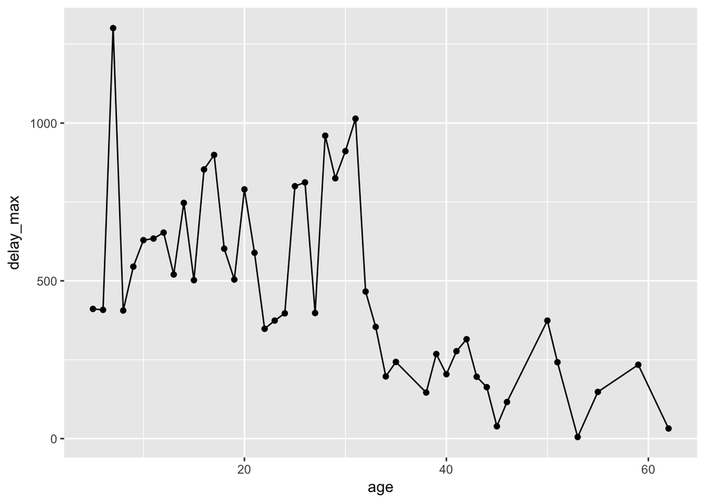

```r
### Maximal minutes of delay
flights %>%
  inner_join(ages_plane, by = "tailnum") %>%
  group_by(age) %>%
  ### Here we use the average
  filter(!is.na(dep_delay)) %>%
  summarise(delay_max = max(dep_delay)) %>%
  ggplot(aes(x = age, y = delay_max)) +
      geom_point() +
      geom_line()
```

## Ex. 14.2.5.2 #2

### Solution 2

```r
str_c("a", c("a","b"), sep = " ", collapse = ",")
```

```
## [1] "a a,a b"
```

```r
str_c("a", c("a","b"), sep = " ")
```

```
## [1] "a a" "a b"
```

## Ex. 15.4.1 #2

> *For each factor in `gss_cat` identify whether the order of the levels is arbitrary or principled.*

### Solution 3

There are five six categorical variables: `marital`, `race`, `rincome`, `partyid`, `relig`, `denom`.

The ordering of martial is *partially* principled. It can be grouped by “never married”, married in the past (separated, divorced, widowed), and “married”

```r
keep(gss_cat, is.factor) %>% names()
```

```
## [1] "marital" "race"    "rincome" "partyid" "relig"   "denom"
```

```r
levels(gss_cat[["marital"]])
```

```
## [1] "No answer"     "Never married" "Separated"     "Divorced"
## [5] "Widowed"       "Married"
```

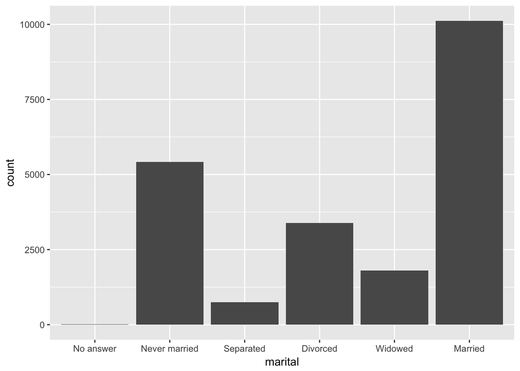

```r
gss_cat %>%
  ggplot(aes(x = marital)) +
  geom_bar()
```

```r
### Obviously, The ordering of race is principled.

levels(gss_cat$race)
```

```
## [1] "Other"          "Black"          "White"          "Not applicable"
```

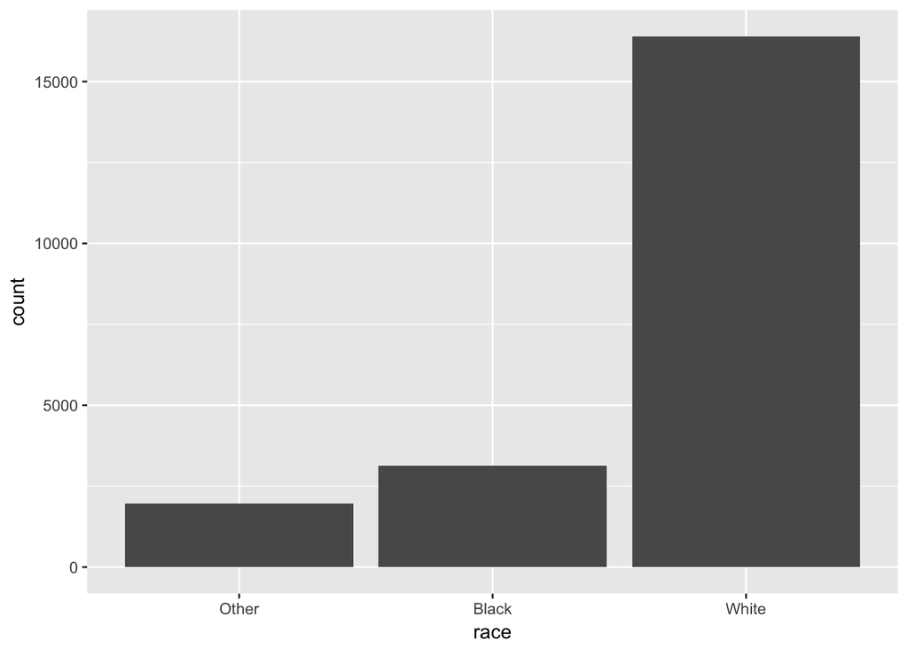

```r
gss_cat %>%
  ggplot(aes(race)) +
  geom_bar(drop = FALSE)
```

```r
###  `rincome` is principledly ordered if we don't take "No answer", "Don't know", "Refused" and "Not applicable" into account, otherwise, it is arbitary.
levels(gss_cat$rincome)
```

```
##  [1] "No answer"      "Don't know"     "Refused"        "$25000 or more"
##  [5] "$20000 - 24999" "$15000 - 19999" "$10000 - 14999" "$8000 to 9999"
##  [9] "$7000 to 7999"  "$6000 to 6999"  "$5000 to 5999"  "$4000 to 4999"
## [13] "$3000 to 3999"  "$1000 to 2999"  "Lt $1000"       "Not applicable"
```

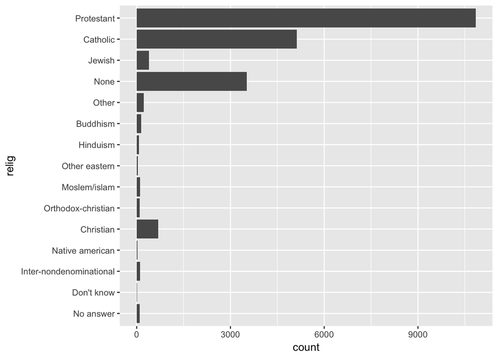

```r
### The levels of `relig` is arbitrary.
gss_cat %>%
  ggplot(aes(relig)) +
  geom_bar() +
  coord_flip()
```

## Ex. 16.3.4 #4

> *How does the average delay time change over the course of a day? Should you use `dep_time` or `sched_dep_time`? Why?*

### Solution 4

`sched_dep_time` is relevant, because the delay time varies with it. So it is used. But `dep_time` is not used explictly here, it is only usded to clean out the missing data.

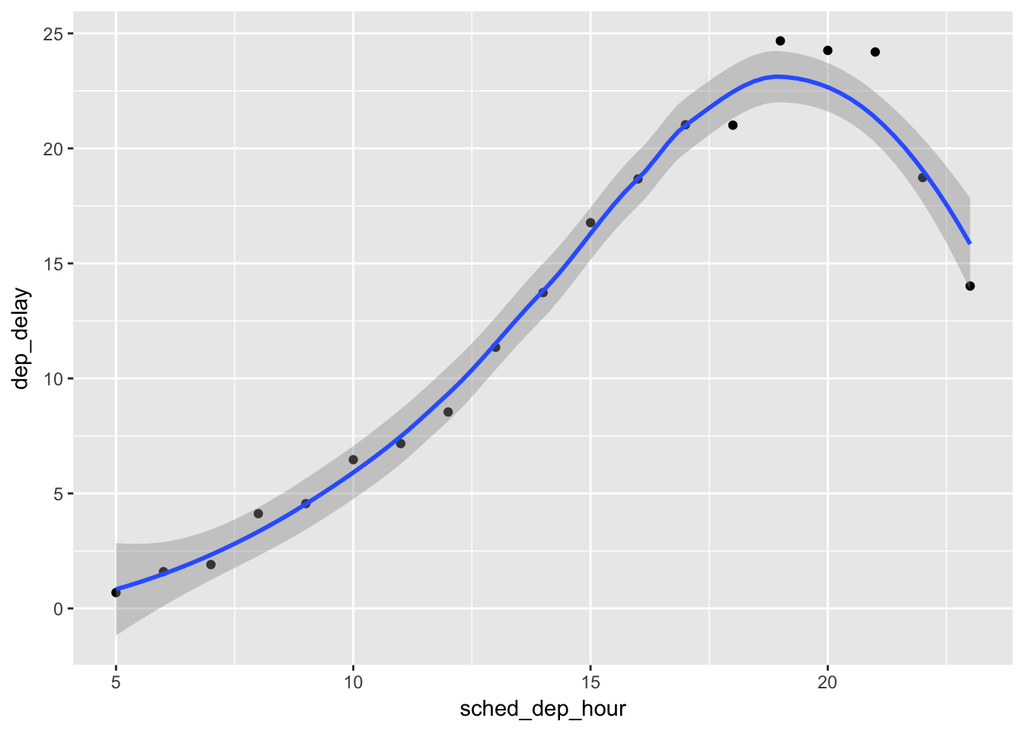

```r
### Convert the time over the day
make_datetime1 <- function(year, month, day, time) {
  make_datetime(year, month, day, time %/% 100, time %% 100)
}

flights1 <- flights %>%
  filter(!is.na(dep_time), !is.na(arr_time)) %>%
  mutate(
    dep_time = make_datetime1(year, month, day, dep_time),
    arr_time = make_datetime1(year, month, day, arr_time),
    sched_dep_time = make_datetime1(year, month, day, sched_dep_time),
    sched_arr_time = make_datetime1(year, month, day, sched_arr_time)
  ) %>%
  select(origin, dest, ends_with("delay"), ends_with("time"))


flights1 %>%
  mutate(sched_dep_hour = hour(sched_dep_time)) %>%
  group_by(sched_dep_hour) %>%
  summarise(dep_delay = mean(dep_delay)) %>%
  ggplot(aes(y = dep_delay, x = sched_dep_hour)) +
  geom_point() +
  geom_smooth()
```

## Contribution

For this lab, firstly, I learned how to use inner_join to match the data, then I know the difference between the sep() and collapse(). In chapter 15, I distinguish the difference between principle and artitrary in gas_cat. For chapter 16, I know to use sch_dep_time, because the delay time varies with the sch_dep_time. It’s better to use sch_dep_time.